# MASZ - Projekt 3 wizualizacja grafów

Ryszard Szymański

3/20/2020

## Definicje funkcji

```r
plot_histogram <- function(values) {
  values_df <- data.frame(
    values = values
  )

  ggplot(values_df, aes(x = values)) +
    geom_histogram()
}

plot_ggraph <- function(graph, layout = "auto") {
  ggraph(graph, layout = layout) +
    geom_edge_link() +
    geom_node_point()
}

plot_with_sigmas <- function(values, values_sd = NULL, sd_breaks) {
  if (is.null(values_sd)) {
    values_sd <- round(sd(values), 2)
  }

  plot_histogram(values) +
    scale_x_continuous(breaks = sd_breaks, labels = paste0(sd_breaks, "\u03C3"))
}

check_pareto_rule <- function(values) {
  threshold <- quantile(values, 0.8)
  percentage <- sum(values[values < threshold]) / sum(values)

  sprintf("%s obserwacji posiada %s wartości", 0.8, percentage)
}
```

## Przypadek normalny

### Zadanie 1

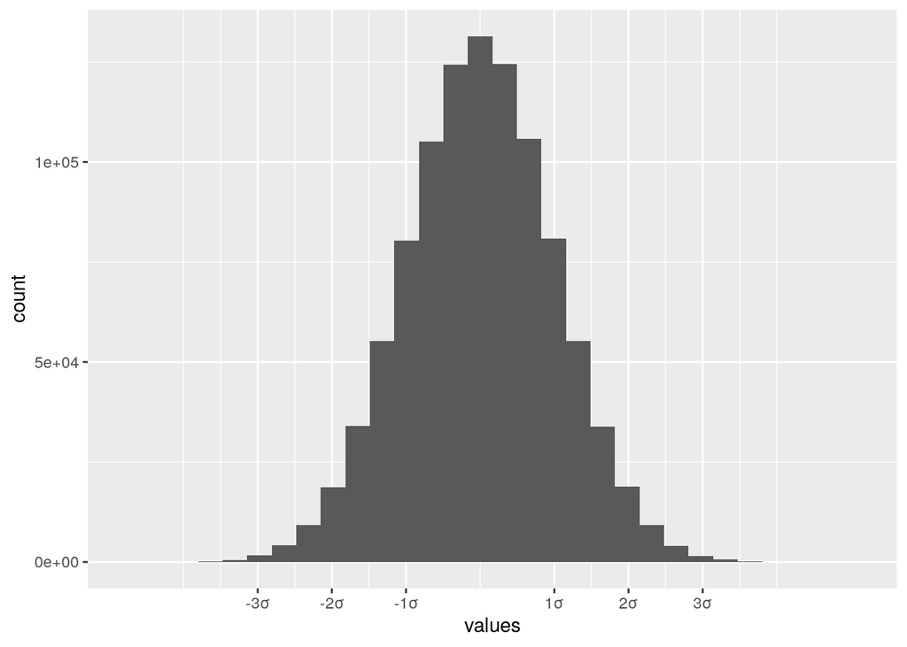

```r
values <- rnorm(n = 1e6)
plot_with_sigmas(values, values_sd = 1, sd_breaks = c(-3, -2, -1, 1, 2, 3))
```

### Zadanie 2

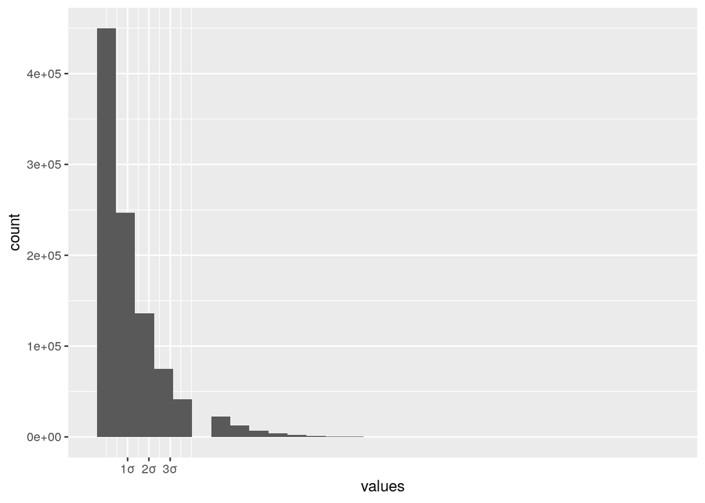

```r
values <- rgeom(1e6, 0.45)

plot_with_sigmas(values, sd_breaks = c(1,2,3))
```

```r
check_pareto_rule(values)
```

```
## [1] "0.8 obserwacji posiada 0.20134087918045 wartości"
```

## Przypadek grubych ogonów

### Zadanie 1

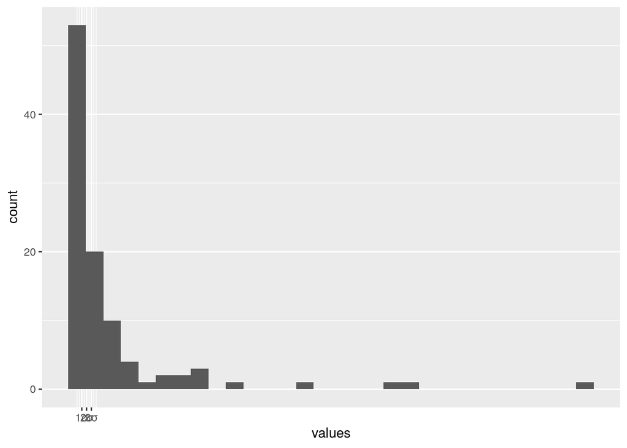

```r
values <- actuar::rinvpareto(1e2, 1, 2)
plot_with_sigmas(values, sd_breaks = c(1,2,3))
```

### Zadanie 2

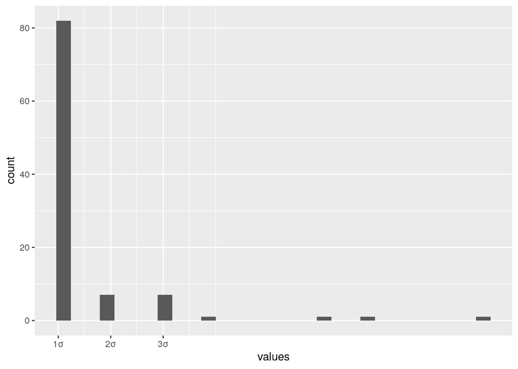

```r
values <- VGAM::rzeta(1e2, 2)

plot_with_sigmas(values, sd_breaks = c(1,2,3))
```

```r
check_pareto_rule(values)
```

```
## [1] "0.8 obserwacji posiada 0 wartości"
```

## Powtórz wcześniejsze ćwiczenia dla rozkładu zipfa

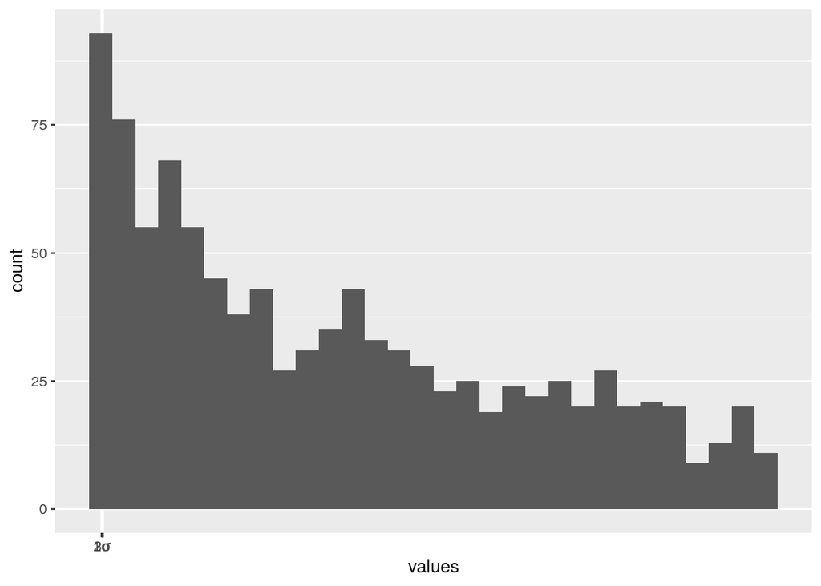

```r
N <- 1e3; shape <- 0.5; y <- 1:N
values <- VGAM::rzipf(y, N = N, shape = shape)
plot_with_sigmas(values, sd_breaks = c(1,2,3))
```

```r
check_pareto_rule(values)
```

```
## [1] "0.8 obserwacji posiada 0.540505889123783 wartości"
```

## Czy rozkład wystarczy?

Kontrprzykład: gwiazdla i graf dwudzielny

```r
star_graph <- igraph::make_star(10, mode="undirected")
bipartite_graph <- igraph::make_full_bipartite_graph(5, 2)

star_graph_plot <- plot_ggraph(star_graph)
```

```
## Using `stress` as default layout
```

```r
star_graph_hist <- plot_histogram(degree(star_graph))

bipartite_graph_plot <- plot_ggraph(bipartite_graph)
```

```
## Using `stress` as default layout
```

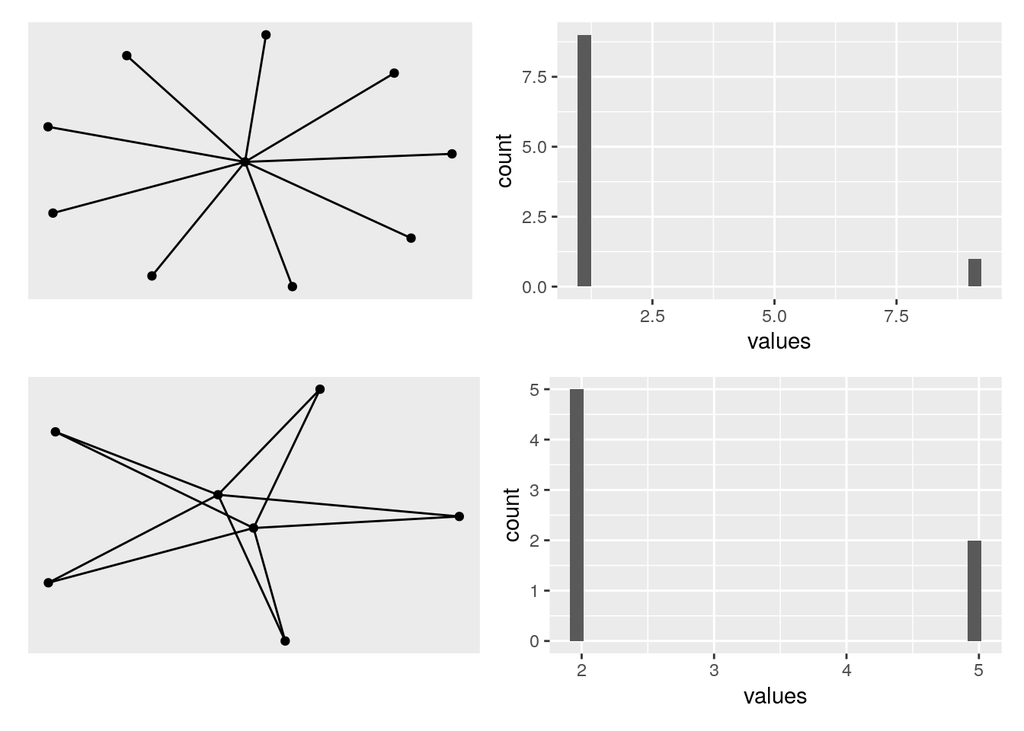

```r
bipartite_graph_hist <- plot_histogram(degree(bipartite_graph))

(star_graph_plot + star_graph_hist) / (bipartite_graph_plot + bipartite_graph_hist)
```

## Czym mogą różnić się sieci o tym samym rozkładzie?

### Sieć dysasortatywna - przykład

Sieć klientów sklepów Lidl, gdzie połączenie oznacza dokonanie transakcji między węzłami. W takiej sieci można by było zauważyć podgrafy zbliżone do grafów typu “gwiazda” (star graph).

### Sieć asortatywna

Sieć odizolowanych od siebie plemion o bardzo różnej wielkości społeczności. Taka sieć składałaby się z podgrafów “prawie-pełnych” (prawie wszyscy się znają w obrębie plemienia)

## Inne cechy wybranych sieci rzeczywistych

- Sieci hierarchiczne - np. sieć pracowników firmy IT. Podstawowym modułem jest zespół pracowników pracujących w ramach jednego zespołu. Zespoły mogą pracować w konkretnych technologiach np. Java, Python. Jeszcze wyżej może być wspólny obszar technologii np. aplikacje webowe.
- Sieci ze strukturą społeczną - np. sieć pracowników firmy Enron, w której połączenie oznacza wymiane maili między pracownikami (na podstawie danych: https://www.cs.cmu.edu/~enron/)

## Metody wizualizacji grafów

### Zadanie 1

https://reference.wolfram.com/language/ref/GraphLayout.html

### Zadanie 2 i 3

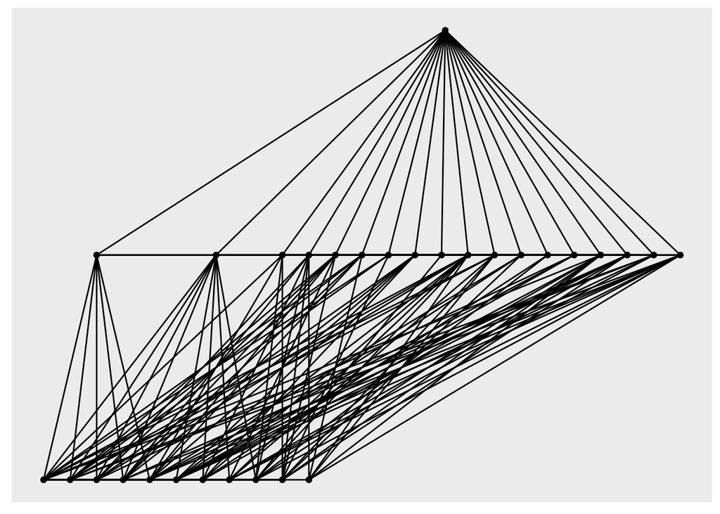

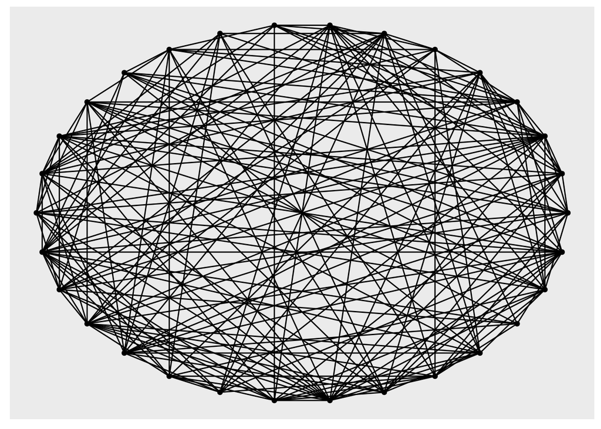

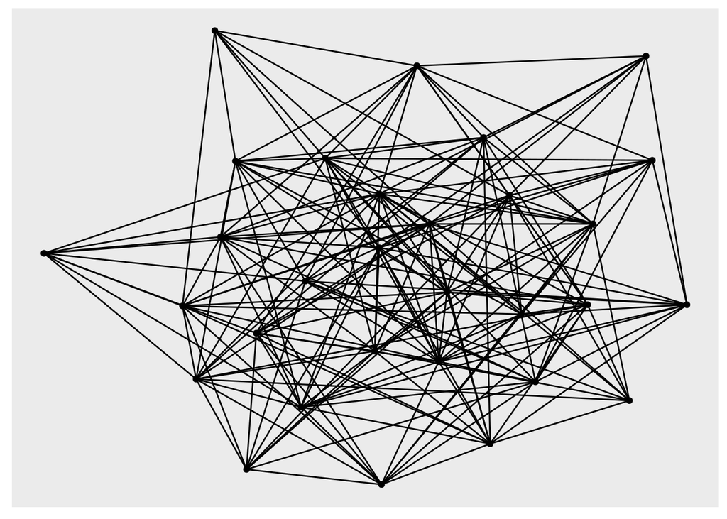

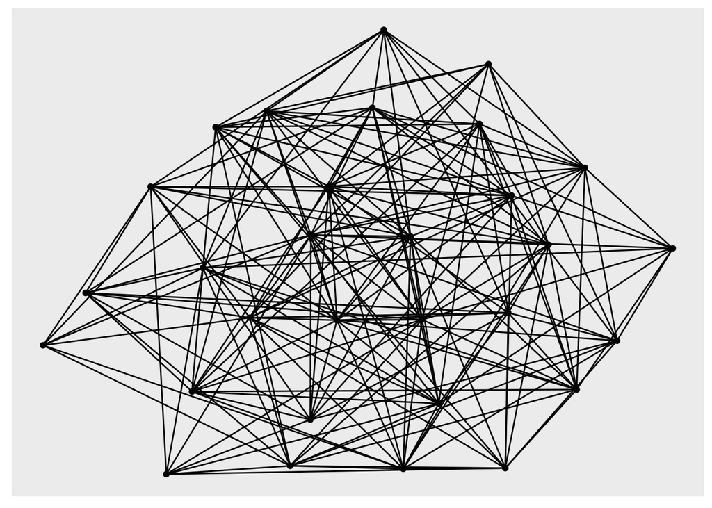

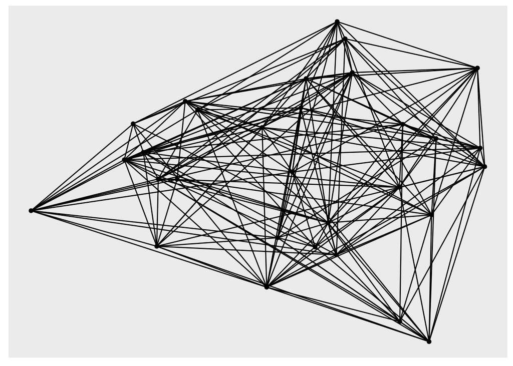

```r
sample_graph <- igraph::erdos.renyi.game(30, 0.4)
algorithms <- c(
  "tree",
  "circle",
  "nicely",
  "kk",
  "mds"
)
lapply(algorithms, function(algorithm) {
  ggraph(sample_graph, layout = "igraph", algorithm = algorithm) +
    geom_node_point() +
    geom_edge_link()
})
```

## Zapisz energie sprężynkowego układu

$U = \frac{k_{e}}{2} \cdot \sum_{i \in V(g)} q_i \cdot \sum_{j \in V(g) \ \land \ j \neq i} \frac{q_j}{d(v_i, v_j)} - \frac{k_{s}}{2} \cdot \sum_{i \in V(g)}\sum_{j \in N_g(i)} d^2(i, j)$, gdzie:

- $k_{e}$ - stała Coulomba
- $V(g)$ - zbiór wierzchołków grafu $g$
- $d(i,j)$ - odległość między wierzchołkami $i$ oraz $j$
- $N_g(i)$ - sąsiedztwo wierzchołak $i$ w grafie $g$
- $q_{i}$ - ładunek $i$-tego wierzchołka

## Narysuj graf w pewnej konfiguracji

W ramach przykładów wygenerowano losowy graf będący cyklem. Poniżej przedstawiono wykres z losową konfiguracją:

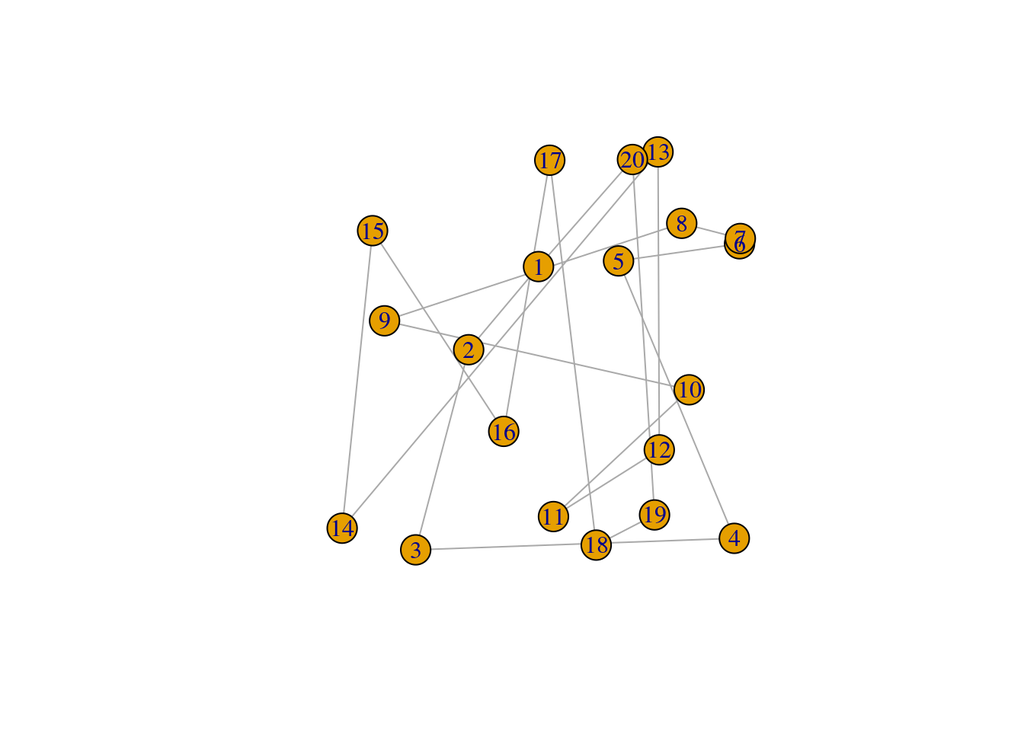

```r
sample_graph <- drake::readd(sample_graph)
sample_layout <- matrix(runif(2 * vcount(sample_graph), -1, 1), ncol = 2)
plot(drake::readd(sample_graph), layout = sample_layout)
```

## Wykonaj animacje

Dokonano własnej implementacji dwóch wariantów symulacji: * Z wykorzystaniem algorytmu Metropolisa * Z wykorzystaniem konkretnych sił, gdzie “fizyka” wykonuje całą robotę i zbiega do stanu o minimum energii. W trakcie implementacji inspirowano się następującą pracą: http://www.it.usyd.edu.au/~peter/old_spring_paper.pdf.

Poniżej zamieszczono animację prezentująca działania algorytmów dla przykładowego grafu z poprzedniego podpunktu.

### Wariant z algorytmem Metropolisa

[interactive chart not shown]

### Wariant “fizyczny”

[interactive chart not shown]

Własne implementacje porównano z algorytmem Fruchtermana-Reingolda:

[interactive chart not shown]

## Obserwacje

- Bardzo duże znaczenie przy implementacji miał:
  - dobór stałych np. stałej określającej rząd przesunięcia wierzchołka
  - pozycje początkowe, w dziwnych przypadkach grafy potrafiły “przeskakiwać” między dwoma skrajnymi stanami

## Zewnętrzne źródła

- www.it.usyd.edu.au/~peter/old_spring_paper.pdf
- https://github.com/gephi/gephi/wiki/Fruchterman-Reingold